# Project Introduction to Computer Vision

# Andres Delgadillo

## 1 Project: Image classification using CNNs in Keras

### 1.1 Objective

We are provided with a dataset of images of plant seedlings at various stages of grown. Each image has a filename that is its unique id. The dataset comprises 12 plant species. The goal of the project is to create a classifier capable of determining a plant's species from a photo.

### 1.2 Import packages and turnoff warnings

```python
import warnings
warnings.filterwarnings("ignore")
from datetime import datetime

import numpy as np
import pandas as pd
import seaborn as sns
import matplotlib.pyplot as plt
import pandas_profiling
sns.set(color_codes=True)
%matplotlib inline

from sklearn.model_selection import train_test_split
from sklearn.preprocessing import StandardScaler
from sklearn import metrics
from sklearn.metrics import f1_score,accuracy_score, recall_score, precision_score, roc_auc_score, roc_curve, confusion_matrix, precision_recall_curve
from sklearn.utils import class_weight

from tensorflow.keras.models import Sequential
from tensorflow.keras.layers import Dense, Dropout
from tensorflow.keras.layers import MaxPooling2D        # Max pooling operation for 2D spatial data.
from tensorflow.keras.layers import Flatten             # Flattens the input. Does not affect the batch size.
from tensorflow.keras.optimizers import Adam
from tensorflow.keras.utils import to_categorical #to perform one-hot encoding
import tensorflow as tf
from tensorflow.keras.layers import Conv2D

import cv2
```

```python
print(datetime.now())
```

```
2021-10-14 11:07:50.936334
```

## 2 Import dataset and quality of data

```python
# read images
data = np.load('images.npy')
# read labels
labels = pd.read_csv('Labels.csv')
```

```python
# print length of data
print(len(data))
print(len(labels))
```

```
4750
4750
```

There are 4750 images with their respective labels

```python
# get size image
data.shape
```

```
(4750, 128, 128, 3)
```

Each image has 128 X 128 X 3 pixels

## 3 Exploratory Data Analysis

### 3.1 Classes

Now, we are going to determine the number of classes and the number of images in each class

```python
# Group of plants
label_groups = labels['Label'].unique()
# print unique labels
print(label_groups)
# print number of plants
print(len(label_groups))
```

```
['Small-flowered Cranesbill' 'Fat Hen' 'Shepherds Purse' 'Common wheat'
 'Common Chickweed' 'Charlock' 'Cleavers' 'Scentless Mayweed' 'Sugar beet'
 'Maize' 'Black-grass' 'Loose Silky-bent']
12
```

There are 12 different plant species

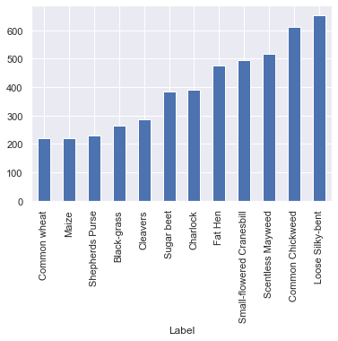

```python
# barplot with number of images for each plant
labels.groupby('Label').size().sort_values().plot.bar();
```

```python
# Proportion of images in each group
labels.groupby('Label').size() / len(labels)
```

```
Label
Black-grass                  0.055368
Charlock                     0.082105
Cleavers                     0.060421
Common Chickweed             0.128632
Common wheat                 0.046526
Fat Hen                      0.100000
Loose Silky-bent             0.137684
Maize                        0.046526
Scentless Mayweed            0.108632
Shepherds Purse              0.048632
Small-flowered Cranesbill    0.104421
Sugar beet                   0.081053
dtype: float64
```

The dataset is unbalanced. `Loose Silky-bent` and `Common Chickweed` have more than 600 images while `Common wheat` and `Maize` have around 200 images

### 3.2 Visualize the images in the dataset

#### 3.2.1 Images for each plant

Now, we are going to visualize the images for each plant

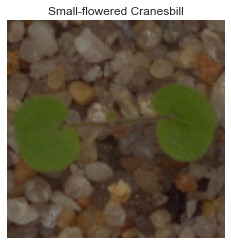

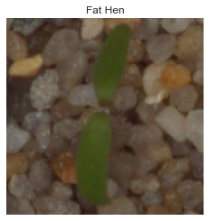

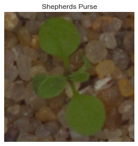

[figure not shown]

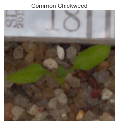

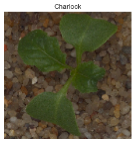

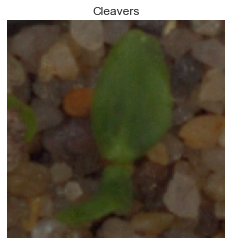

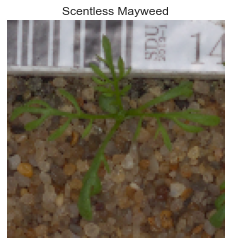

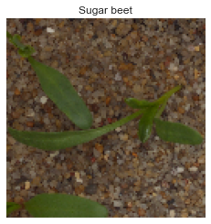

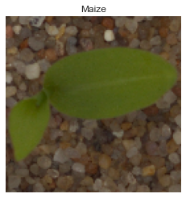

[figure not shown]

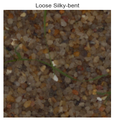

```python
# visualize first image in each group
for label in label_groups:
    img = cv2.cvtColor(data[ labels[labels['Label'] == label].index[0] ], cv2.COLOR_BGR2RGB)
    plt.figure()
    plt.title(label)
    plt.imshow(img)
    plt.axis('off')
```

#### 3.2.2 Mean images for each class

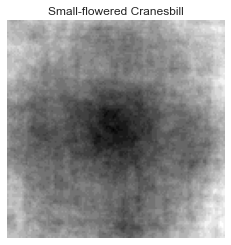

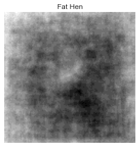

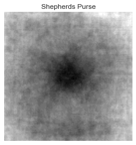

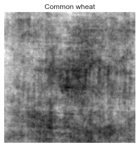

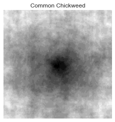

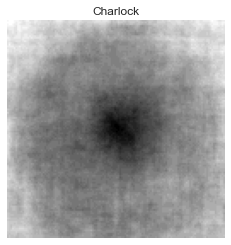

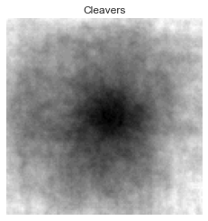

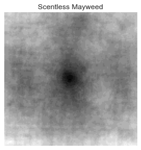

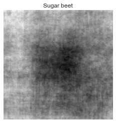

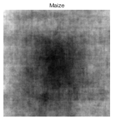

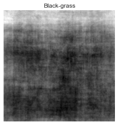

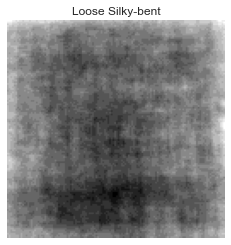

```python
# visualize mean image in each group
for label in label_groups:
    # calculate mean image
    img = np.rint(np.mean(data[labels[labels['Label'] == label].index], axis=0)).astype('uint8')
    # visualize images in gray scale
    img = cv2.cvtColor(img, cv2.COLOR_RGB2GRAY)
    plt.figure()
    plt.title(label)
    plt.imshow(img, cmap="gray")
    plt.axis('off')
```